# IBM LAB 7.5

# 1 IMPORTING AND FORMATTING THE DATA

We first have to load the needed librarires

```r
library(tidyverse)
```

Let’s load the data from the IBM dataset, using the “*download.file()*” formula

```r
url <- "https://dax-cdn.cdn.appdomain.cloud/dax-airline/1.0.1/lax_to_jfk.tar.gz"

download.file(url, destfile = "lax_to_jfk.tar.gz")

untar("lax_to_jfk.tar.gz", tar = "internal")
data_airline <- read_csv("lax_to_jfk/lax_to_jfk.csv")
head(data_airline)
```

```
## # A tibble: 6 × 21
##   Month DayOfW…¹ FlightDate Repor…² Origin Dest  CRSDe…³ CRSAr…⁴ DepTime ArrTime
##   <dbl>    <dbl> <date>     <chr>   <chr>  <chr> <chr>   <chr>   <chr>   <chr>
## 1     3        5 2003-03-28 UA      LAX    JFK   2210    0615    2209    0617
## 2    11        4 2018-11-29 AS      LAX    JFK   1045    1912    1049    1851
## 3     8        5 2015-08-28 UA      LAX    JFK   0805    1634    0757    1620
## 4     4        7 2003-04-20 DL      LAX    JFK   2205    0619    2212    0616
## 5    11        3 2005-11-30 UA      LAX    JFK   0840    1653    0836    1640
## 6     4        1 1992-04-06 UA      LAX    JFK   1450    2308    1452    2248
## # … with 11 more variables: ArrDelay <dbl>, ArrDelayMinutes <dbl>,
## #   CarrierDelay <dbl>, WeatherDelay <dbl>, NASDelay <dbl>,
## #   SecurityDelay <dbl>, LateAircraftDelay <dbl>, DepDelay <dbl>,
## #   DepDelayMinutes <dbl>, DivDistance <lgl>, DivArrDelay <lgl>, and
## #   abbreviated variable names ¹DayOfWeek, ²Reporting_Airline, ³CRSDepTime,
## #   ⁴CRSArrTime
```

We can check the format type with “*glimpse()*” in order to see the columns name and the relative format

```r
glimpse(data_airline)
```

```
## Rows: 2,855
## Columns: 21
## $ Month             <dbl> 3, 11, 8, 4, 11, 4, 12, 12, 2, 3, 10, 8, 6, 2, 8, 3,…
## $ DayOfWeek         <dbl> 5, 4, 5, 7, 3, 1, 1, 3, 4, 4, 4, 5, 4, 3, 7, 6, 4, 4…
## $ FlightDate        <date> 2003-03-28, 2018-11-29, 2015-08-28, 2003-04-20, 200…
## $ Reporting_Airline <chr> "UA", "AS", "UA", "DL", "UA", "UA", "VX", "HP", "UA"…
## $ Origin            <chr> "LAX", "LAX", "LAX", "LAX", "LAX", "LAX", "LAX", "LA…
## $ Dest              <chr> "JFK", "JFK", "JFK", "JFK", "JFK", "JFK", "JFK", "JF…
## $ CRSDepTime        <chr> "2210", "1045", "0805", "2205", "0840", "1450", "104…
## $ CRSArrTime        <chr> "0615", "1912", "1634", "0619", "1653", "2308", "190…
## $ DepTime           <chr> "2209", "1049", "0757", "2212", "0836", "1452", "103…
## $ ArrTime           <chr> "0617", "1851", "1620", "0616", "1640", "2248", "190…
## $ ArrDelay          <dbl> 2, -21, -14, -3, -13, -20, 1, -40, 25, 7, 5, 34, 21,…
## $ ArrDelayMinutes   <dbl> 2, 0, 0, 0, 0, 0, 1, 0, 25, 7, 5, 34, 21, 0, 14, 682…
## $ CarrierDelay      <dbl> NA, NA, NA, NA, NA, NA, NA, NA, NA, NA, NA, 11, 0, N…
## $ WeatherDelay      <dbl> NA, NA, NA, NA, NA, NA, NA, NA, NA, NA, NA, 0, 0, NA…
## $ NASDelay          <dbl> NA, NA, NA, NA, NA, NA, NA, NA, NA, NA, NA, 23, 21, …
## $ SecurityDelay     <dbl> NA, NA, NA, NA, NA, NA, NA, NA, NA, NA, NA, 0, 0, NA…
## $ LateAircraftDelay <dbl> NA, NA, NA, NA, NA, NA, NA, NA, NA, NA, NA, 0, 0, NA…
## $ DepDelay          <dbl> -1, 4, -8, 7, -4, 2, -2, -2, 2, 15, 2, 21, -8, -2, -…
## $ DepDelayMinutes   <dbl> 0, 4, 0, 7, 0, 2, 0, 0, 2, 15, 2, 21, 0, 0, 0, 395, …
## $ DivDistance       <lgl> NA, NA, NA, NA, NA, NA, NA, NA, NA, NA, NA, NA, NA, …
## $ DivArrDelay       <lgl> NA, NA, NA, NA, NA, NA, NA, NA, NA, NA, NA, NA, NA, …
```

We can see that the last two columns “DivDistance” and “DivArrDelay” are set as logical factors, to overcome that and set them as numeric we can reformulate the “*read_csv()*” of the data set by introducing “*col_types()*”

```r
data_airline <- read_csv("lax_to_jfk/lax_to_jfk.csv",
                         col_types = cols(
                           "DivDistance" = col_number(),
                           "DivArrDelay" = col_number()
                         ))

glimpse(data_airline)
```

```
## Rows: 2,855
## Columns: 21
## $ Month             <dbl> 3, 11, 8, 4, 11, 4, 12, 12, 2, 3, 10, 8, 6, 2, 8, 3,…
## $ DayOfWeek         <dbl> 5, 4, 5, 7, 3, 1, 1, 3, 4, 4, 4, 5, 4, 3, 7, 6, 4, 4…
## $ FlightDate        <date> 2003-03-28, 2018-11-29, 2015-08-28, 2003-04-20, 200…
## $ Reporting_Airline <chr> "UA", "AS", "UA", "DL", "UA", "UA", "VX", "HP", "UA"…
## $ Origin            <chr> "LAX", "LAX", "LAX", "LAX", "LAX", "LAX", "LAX", "LA…
## $ Dest              <chr> "JFK", "JFK", "JFK", "JFK", "JFK", "JFK", "JFK", "JF…
## $ CRSDepTime        <chr> "2210", "1045", "0805", "2205", "0840", "1450", "104…
## $ CRSArrTime        <chr> "0615", "1912", "1634", "0619", "1653", "2308", "190…
## $ DepTime           <chr> "2209", "1049", "0757", "2212", "0836", "1452", "103…
## $ ArrTime           <chr> "0617", "1851", "1620", "0616", "1640", "2248", "190…
## $ ArrDelay          <dbl> 2, -21, -14, -3, -13, -20, 1, -40, 25, 7, 5, 34, 21,…
## $ ArrDelayMinutes   <dbl> 2, 0, 0, 0, 0, 0, 1, 0, 25, 7, 5, 34, 21, 0, 14, 682…
## $ CarrierDelay      <dbl> NA, NA, NA, NA, NA, NA, NA, NA, NA, NA, NA, 11, 0, N…
## $ WeatherDelay      <dbl> NA, NA, NA, NA, NA, NA, NA, NA, NA, NA, NA, 0, 0, NA…
## $ NASDelay          <dbl> NA, NA, NA, NA, NA, NA, NA, NA, NA, NA, NA, 23, 21, …
## $ SecurityDelay     <dbl> NA, NA, NA, NA, NA, NA, NA, NA, NA, NA, NA, 0, 0, NA…
## $ LateAircraftDelay <dbl> NA, NA, NA, NA, NA, NA, NA, NA, NA, NA, NA, 0, 0, NA…
## $ DepDelay          <dbl> -1, 4, -8, 7, -4, 2, -2, -2, 2, 15, 2, 21, -8, -2, -…
## $ DepDelayMinutes   <dbl> 0, 4, 0, 7, 0, 2, 0, 0, 2, 15, 2, 21, 0, 0, 0, 395, …
## $ DivDistance       <dbl> NA, NA, NA, NA, NA, NA, NA, NA, NA, NA, NA, NA, NA, …
## $ DivArrDelay       <dbl> NA, NA, NA, NA, NA, NA, NA, NA, NA, NA, NA, NA, NA, …
```

# 2 REGRESSION

The regression analysis is a useful tool to asses the correlation between two variables, named respectively x and y, where the first is the PREDICTOR and INDIPENDENT variable, while the second is the RESPONSE and DEPENDENT variable. We can perform a variety of regression analysis on the data, those includes, Simple Linear, Multiple Linear and Polynomial Regression

## 2.1 SIMPLE LINEAR REGRESSION

```r
alaska_delay <- data_airline |>
  filter(CarrierDelay != "NA", Reporting_Airline == "AA")

head(alaska_delay)
```

```
## # A tibble: 6 × 21
##   Month DayOfW…¹ FlightDate Repor…² Origin Dest  CRSDe…³ CRSAr…⁴ DepTime ArrTime
##   <dbl>    <dbl> <date>     <chr>   <chr>  <chr> <chr>   <chr>   <chr>   <chr>
## 1     6        4 2006-06-01 AA      LAX    JFK   1515    2332    1507    2353
## 2     6        5 2013-06-28 AA      LAX    JFK   1200    2045    1328    2220
## 3    10        3 2005-10-12 AA      LAX    JFK   0930    1755    0958    1823
## 4     4        6 2011-04-23 AA      LAX    JFK   0925    1800    1040    1850
## 5     8        7 2011-08-14 AA      LAX    JFK   1100    1945    1200    2042
## 6     2        5 2004-02-06 AA      LAX    JFK   1500    2306    1607    2348
## # … with 11 more variables: ArrDelay <dbl>, ArrDelayMinutes <dbl>,
## #   CarrierDelay <dbl>, WeatherDelay <dbl>, NASDelay <dbl>,
## #   SecurityDelay <dbl>, LateAircraftDelay <dbl>, DepDelay <dbl>,
## #   DepDelayMinutes <dbl>, DivDistance <dbl>, DivArrDelay <dbl>, and
## #   abbreviated variable names ¹DayOfWeek, ²Reporting_Airline, ³CRSDepTime,
## #   ⁴CRSArrTime
```

To perform the simple linear regression, use the formula “*lm()*”

```r
linear_model <- lm(ArrDelayMinutes ~ DepDelayMinutes, data = alaska_delay)

summary(linear_model)
```

```
##
## Call:
## lm(formula = ArrDelayMinutes ~ DepDelayMinutes, data = alaska_delay)
##
## Residuals:
##     Min      1Q  Median      3Q     Max
## -37.234 -12.716  -1.354   7.747  93.646
##
## Coefficients:
##                 Estimate Std. Error t value Pr(>|t|)
## (Intercept)      17.3544     2.5084   6.919  2.9e-10 ***
## DepDelayMinutes   0.7523     0.0399  18.855  < 2e-16 ***
## ---
## Signif. codes:  0 '***' 0.001 '**' 0.01 '*' 0.05 '.' 0.1 ' ' 1
##
## Residual standard error: 20.03 on 113 degrees of freedom
## Multiple R-squared:  0.7588, Adjusted R-squared:  0.7567
## F-statistic: 355.5 on 1 and 113 DF,  p-value: < 2.2e-16
```

Printing the summary, we can find out the values of **b0** and **b1**, that in that case are 17.354 and 0.7523. We can now perform a prediction on three new value based on the training data set that we just executed.

```r
new_depdelay <- data.frame(
  DepDelayMinutes = c(12, 19, 24)
)

predicted_value <- predict(linear_model, newdata = new_depdelay, interval = "confidence")

predicted_value
```

```
##        fit      lwr      upr
## 1 26.38175 21.98838 30.77512
## 2 31.64769 27.52630 35.76908
## 3 35.40907 31.44593 39.37222
```

We receive a table with three columns values. The first, **fit**, is the most common value that we are probably going to incur into; the other two, **lwr** and the **upr**, are the lowest and highest value of a confident range of occurrence. To visualize the coefficients we may filter the data set with the *$*.

```r
linear_model$coefficients
```

```
##     (Intercept) DepDelayMinutes
##      17.3544286       0.7522769
```

### 2.1.1 EXERCISE LINEAR REGRESSION

Practice those formulas by analyzing the relation in between Carrier Delay and the Arrival Delay with a linear model 2.

**1. Find the linear regression between Carrier Delay and Arrival Delay**

**Click here to see the solution.**

```r
linear_model2 <- lm(ArrDelayMinutes ~ CarrierDelay, data = alaska_delay)

summary(linear_model2)
```

```
##
## Call:
## lm(formula = ArrDelayMinutes ~ CarrierDelay, data = alaska_delay)
##
## Residuals:
##     Min      1Q  Median      3Q     Max
## -30.665 -17.259  -9.276   6.515 155.882
##
## Coefficients:
##              Estimate Std. Error t value Pr(>|t|)
## (Intercept)  35.11761    3.38591  10.372  < 2e-16 ***
## CarrierDelay  0.70318    0.08276   8.497 8.93e-14 ***
## ---
## Signif. codes:  0 '***' 0.001 '**' 0.01 '*' 0.05 '.' 0.1 ' ' 1
##
## Residual standard error: 31.85 on 113 degrees of freedom
## Multiple R-squared:  0.3898, Adjusted R-squared:  0.3844
## F-statistic:  72.2 on 1 and 113 DF,  p-value: 8.927e-14
```

**2. Predict the Arrival Delay for a Carrier Delay of c(2, 4, 5, 0)**

**Click here to see the solution.**

```r
new_carrDelay <- data.frame(
  CarrierDelay = c(2, 4, 5, 0)
)

predicted_value2 <- predict(linear_model2, newdata = new_carrDelay, interval = "confidence")

predicted_value2
```

```
##        fit      lwr      upr
## 1 36.52396 29.96699 43.08094
## 2 37.93032 31.51126 44.34937
## 3 38.63349 32.27817 44.98882
## 4 35.11761 28.40952 41.82571
```

## 2.2 MULTIPLE LINEAR REGRESSION

The multiple linear regression can perform prediction on a variable, in that case the Arrival Delay, based on the analysis of different predictor variables. Taking into consideration the simple linear regression formula, we can add the new variable consideration at the end of it. It would now be “**Y = b0 + b1X1 + b2X2**”. Let’s practice with the predictor variables of DepDelayMinutes and LateAircraftDelay.

```r
multiple_model <- lm(ArrDelayMinutes ~ DepDelayMinutes + LateAircraftDelay, data = alaska_delay)

summary(multiple_model)
```

```
##
## Call:
## lm(formula = ArrDelayMinutes ~ DepDelayMinutes + LateAircraftDelay,
##     data = alaska_delay)
##
## Residuals:
##     Min      1Q  Median      3Q     Max
## -37.188 -12.545  -1.317   7.791  93.683
##
## Coefficients:
##                   Estimate Std. Error t value Pr(>|t|)
## (Intercept)       17.31707    2.53786   6.823 4.78e-10 ***
## DepDelayMinutes    0.75556    0.04822  15.668  < 2e-16 ***
## LateAircraftDelay -0.01028    0.08407  -0.122    0.903
## ---
## Signif. codes:  0 '***' 0.001 '**' 0.01 '*' 0.05 '.' 0.1 ' ' 1
##
## Residual standard error: 20.11 on 112 degrees of freedom
## Multiple R-squared:  0.7588, Adjusted R-squared:  0.7545
## F-statistic: 176.2 on 2 and 112 DF,  p-value: < 2.2e-16
```

### 2.2.1 EXERCISE MULTIPLE REGRESSION

Practice those formulas by analyzing the relation in between Arrival Delay and the predictor values of Carrier Delay, Late Aircraft and Departure Delay.

**1. Find the multiple regression**

**Click here to see the solution.**

```r
multiple_model2 <- lm(ArrDelayMinutes ~ DepDelayMinutes + CarrierDelay + LateAircraftDelay, data = alaska_delay)

summary(multiple_model2)
```

```
##
## Call:
## lm(formula = ArrDelayMinutes ~ DepDelayMinutes + CarrierDelay +
##     LateAircraftDelay, data = alaska_delay)
##
## Residuals:
##     Min      1Q  Median      3Q     Max
## -33.711 -12.875  -0.265   6.105  92.735
##
## Coefficients:
##                   Estimate Std. Error t value Pr(>|t|)
## (Intercept)        18.2650     2.5820   7.074 1.43e-10 ***
## DepDelayMinutes     0.6107     0.0995   6.137 1.33e-08 ***
## CarrierDelay        0.1799     0.1083   1.661   0.0996 .
## LateAircraftDelay   0.1536     0.1292   1.189   0.2370
## ---
## Signif. codes:  0 '***' 0.001 '**' 0.01 '*' 0.05 '.' 0.1 ' ' 1
##
## Residual standard error: 19.96 on 111 degrees of freedom
## Multiple R-squared:  0.7647, Adjusted R-squared:  0.7583
## F-statistic: 120.2 on 3 and 111 DF,  p-value: < 2.2e-16
```

**2. Find the predicted value of Arrival Delay based on those new data**

```r
DepDelayMinutes <- c(10, 20, 30)
LateAircraftDelay <- c(20, 60, 30)

new_predictordata <- data.frame(DepDelayMinutes, LateAircraftDelay)

new_predictordata
```

```
##   DepDelayMinutes LateAircraftDelay
## 1              10                20
## 2              20                60
## 3              30                30
```

**Click here to see the solution.**

```r
predicted_value_mlr <- predict(multiple_model, newdata = new_predictordata, interval = "confidence")

predicted_value_mlr
```

```
##        fit      lwr      upr
## 1 24.66712 19.02312 30.31112
## 2 31.81167 21.42849 42.19485
## 3 39.67548 34.12732 45.22364
```

## 2.3 ASSESSING MODELS VISUALLY

### 2.3.1 REGRESSING PLOT

Once we have different analysis, we have to asses which one of them has the best fit and to do so we can use the Regression plot to have a visual understanding of the relation. Using “*ggplot()*” we can achieve a set of charts. Let’s do the analysis on the Departure and Arrival delay regression.

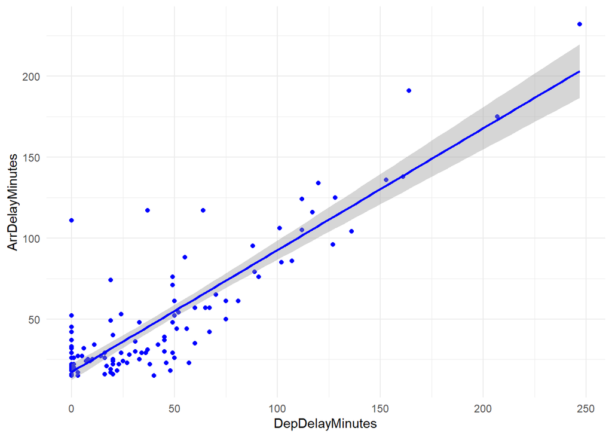

```r
alaska_delay |>
  ggplot(aes(DepDelayMinutes, ArrDelayMinutes)) +
  geom_point(col = "blue") +
  stat_smooth(method = "lm", col = "blue") +
  theme_minimal()
```

We can see from this plot that Arrival Delay Minutes is positively correlated to Departure Delay Minutes, since the regression slope is positive.

### 2.3.2 EXERCISE PLOT REGRESSION

Practice printing different regression plots.

**Click here to see the solution.**

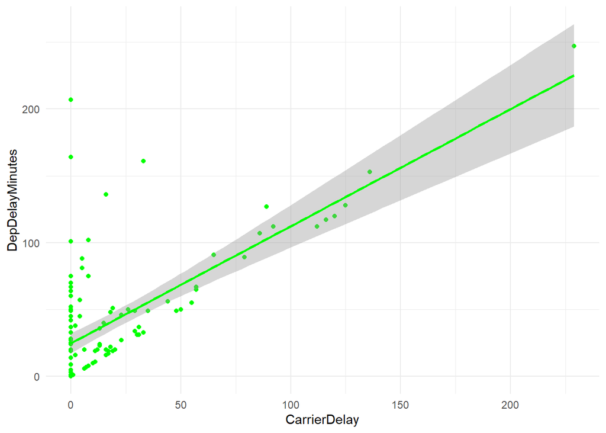

```r
alaska_delay |>
  ggplot(aes(CarrierDelay, DepDelayMinutes)) +
  geom_point(col = "green") +
  stat_smooth(method = "lm", col = "green") +
  theme_minimal()
```

## 2.4 RESIDUAL PLOT

A residual plot analyzes the difference between the **Observed Values** and the **Predicted Values** and suggest the best fit for regression model by the chart result.

We have to first include in the data, a new column with the predicted values so we can compare the predicted with the observed. To do so we can use the linear model used at the beginning of the chapter.

```r
alaska_model2 <- data_airline |>
  filter(Reporting_Airline == "AA", CarrierDelay != "NA")

linear_model_alaska <- lm(ArrDelayMinutes ~ DepDelayMinutes, data = alaska_model2)

alaska_model2$PredictedDelay <- predict(linear_model_alaska)

head(alaska_model2)
```

```
## # A tibble: 6 × 22
##   Month DayOfW…¹ FlightDate Repor…² Origin Dest  CRSDe…³ CRSAr…⁴ DepTime ArrTime
##   <dbl>    <dbl> <date>     <chr>   <chr>  <chr> <chr>   <chr>   <chr>   <chr>
## 1     6        4 2006-06-01 AA      LAX    JFK   1515    2332    1507    2353
## 2     6        5 2013-06-28 AA      LAX    JFK   1200    2045    1328    2220
## 3    10        3 2005-10-12 AA      LAX    JFK   0930    1755    0958    1823
## 4     4        6 2011-04-23 AA      LAX    JFK   0925    1800    1040    1850
## 5     8        7 2011-08-14 AA      LAX    JFK   1100    1945    1200    2042
## 6     2        5 2004-02-06 AA      LAX    JFK   1500    2306    1607    2348
## # … with 12 more variables: ArrDelay <dbl>, ArrDelayMinutes <dbl>,
## #   CarrierDelay <dbl>, WeatherDelay <dbl>, NASDelay <dbl>,
## #   SecurityDelay <dbl>, LateAircraftDelay <dbl>, DepDelay <dbl>,
## #   DepDelayMinutes <dbl>, DivDistance <dbl>, DivArrDelay <dbl>,
## #   PredictedDelay <dbl>, and abbreviated variable names ¹DayOfWeek,
## #   ²Reporting_Airline, ³CRSDepTime, ⁴CRSArrTime
```

And now we can create the Residual plot using “**ggplot()**”

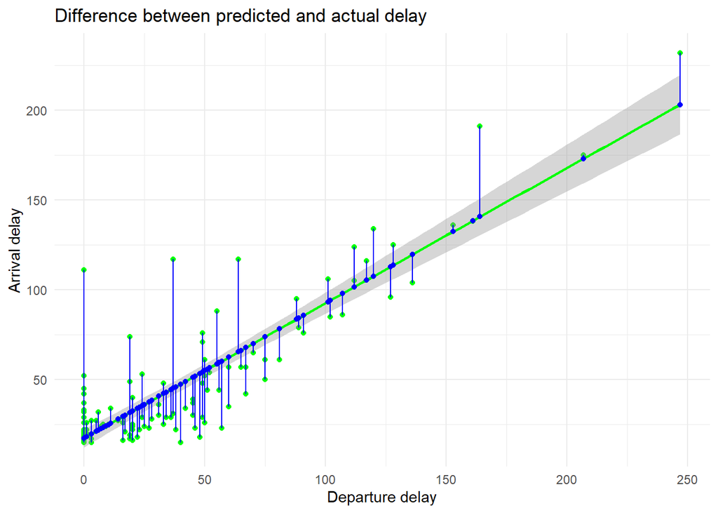

```r
alaska_model2 |>
  ggplot(aes(DepDelayMinutes, ArrDelayMinutes)) +
  geom_point(col = "green") +
  geom_smooth(method = "lm", col = "green") +
  geom_segment(aes(xend= DepDelayMinutes, yend = PredictedDelay), col = "blue") +
  geom_point(aes(y = PredictedDelay), col = "blue") +
  theme_minimal() +
  ggtitle("Difference between predicted and actual delay") +
  labs(x = "Departure delay", y = "Arrival delay")
```

## 2.5 OTHER PLOTS

Using the “**plot()*” formula for a linear model, we will display 4 different plots. RESIDUAL POLT, as shown above, Q-Q PLOT displays what normally distributed residual values would follow, SCALE LOCATION PLOT Help checking the homoscedasticity that whenever the line is not straight it’s not validated, RESIDUAL VS LEVERAGE PLOT displays two dotted lines that signify the range outside which the values would be influential enough to modify the result.

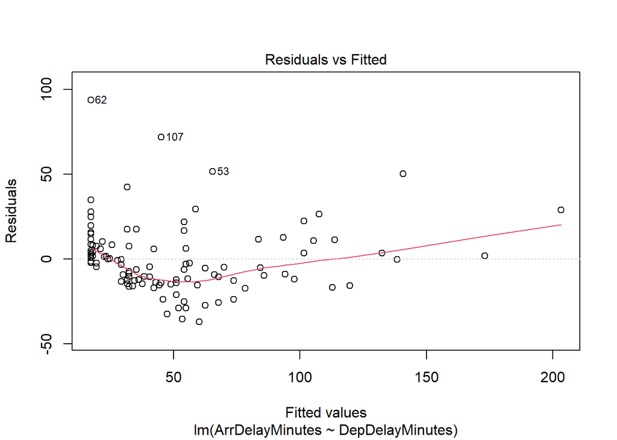

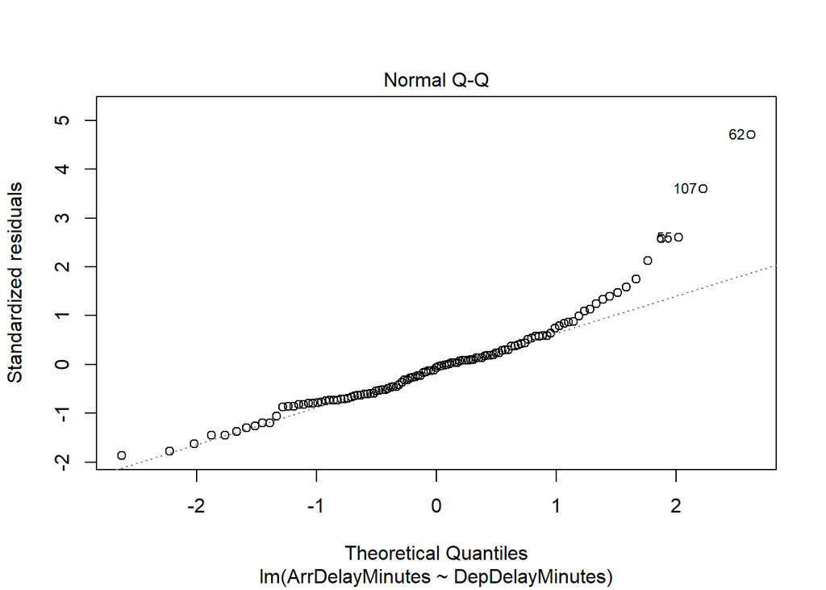

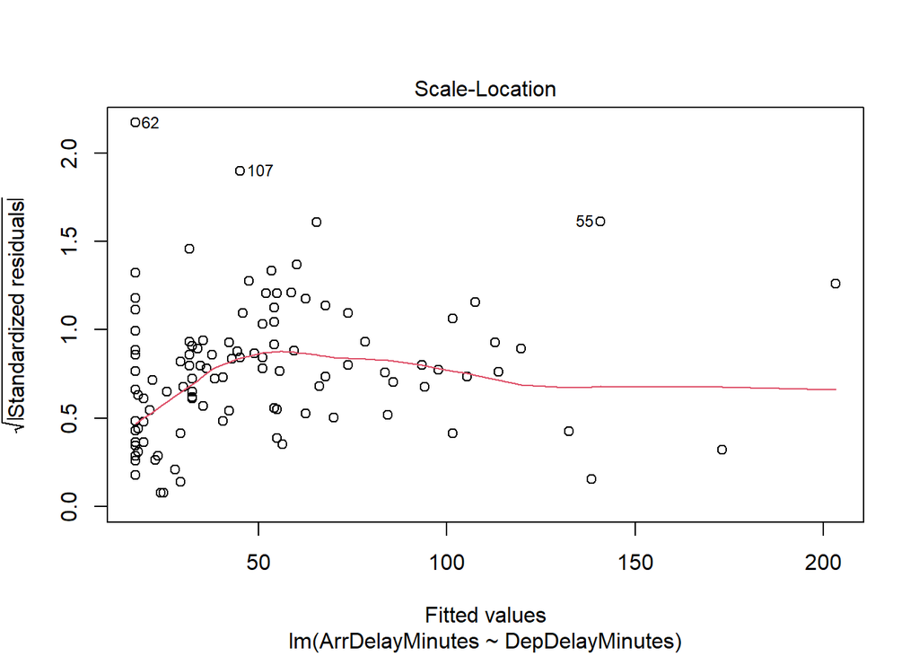

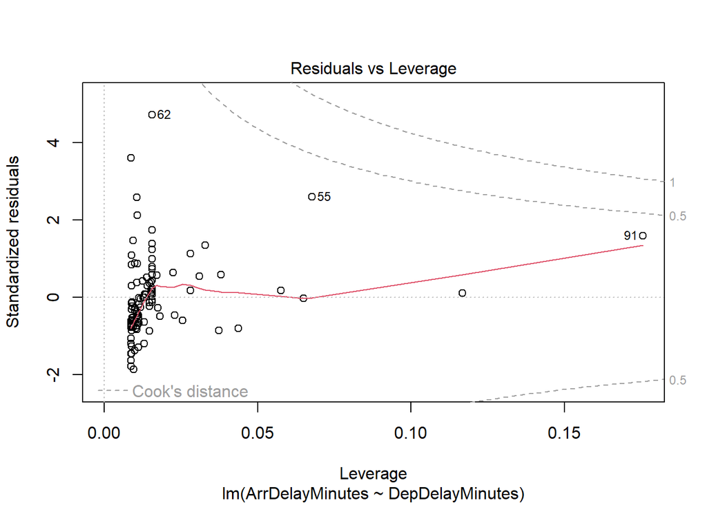

```r
plot(linear_model)
```

# 3 POLYNOMIAL REGRESSION

Polynomial regression is a particular case of the general linear regression model or multiple linear regression models. That is, although the data is nonlinear in polynomial regression (the predicator variables have higher order terms), the model in all cases is linear. (I dati sono sinuosi nel grafico ma la analisi che stiamo eseguendo è per trovare una linea lineare generale che lo possa descrivere, guarda il grafico per capire a pieno) Let’s make an example.

```r
x <- seq(from = 0, to = 20, by = 0.1)

y <- 500 + 0.4 * (x-10)^3

noise <- rnorm(length(x), mean = 10, sd = 80)

noisy.y <- y + noise
```

The representation would look like that

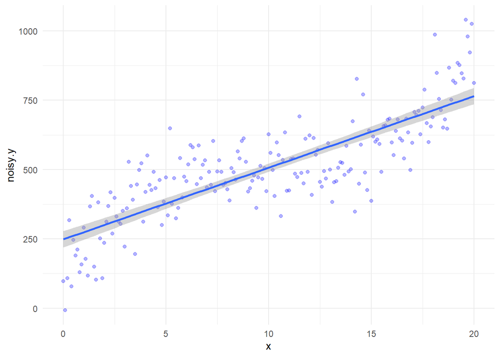

```r
ggplot(data = NULL, aes(x, noisy.y)) +
  geom_point(color = "blue", alpha = 0.3) +
  geom_smooth(method = "lm") +
  theme_minimal()
```

Instead, to have a very closer line representation, we can introduce in the “**geom_smooth()**” argument, the formula “**formula = y ~ poly(x, 5)**” where 5 is the exponential factor.

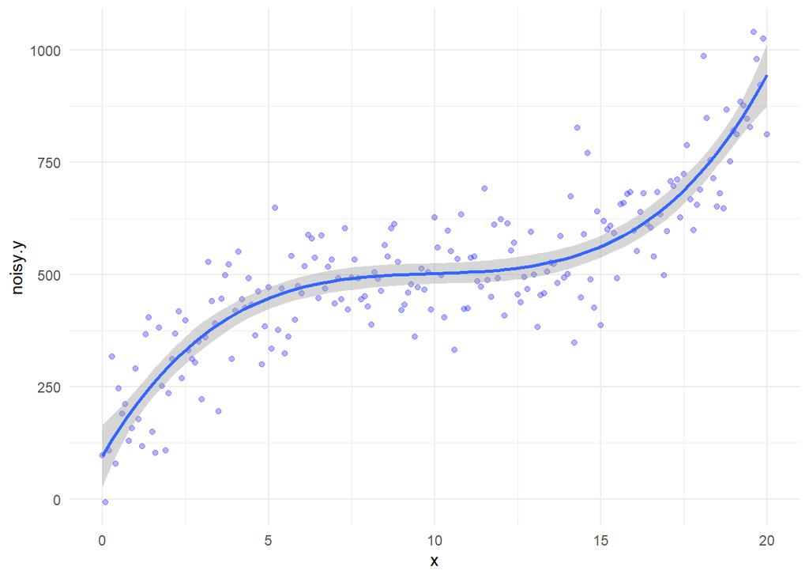

```r
ggplot(data = NULL, aes(x, noisy.y)) +
  geom_point(color = "blue", alpha = 0.3) +
  geom_smooth(method = "lm", formula = y ~ poly ( x, 5)) +
  theme_minimal()
```

We can also create a second level model.

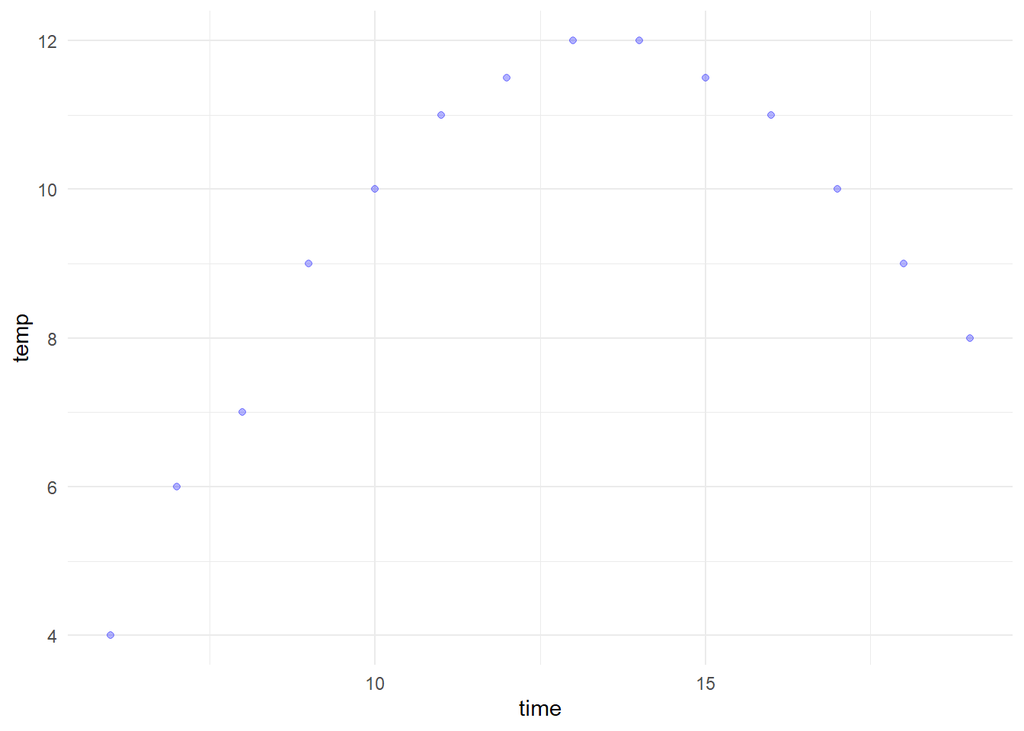

```r
time <- 6:19
temp <- c(4,6,7,9,10,11,11.5,12,12,11.5,11,10,9,8)

ggplot(data = NULL, aes(time, temp)) +
  geom_point(color = "blue", alpha = 0.3) +
  theme_minimal()
```

```r
poly_model <- lm(temp ~ poly(time, 2, raw = TRUE))
```

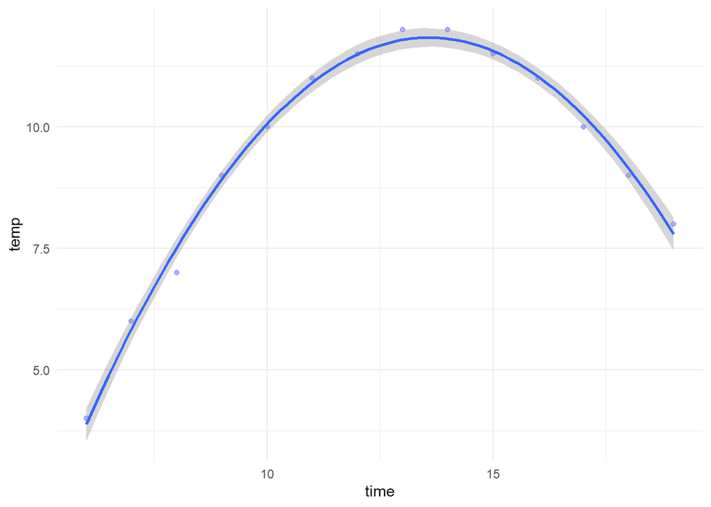

```r
ggplot(data = NULL, aes(time, temp)) +
    geom_point(color = "blue", alpha = 0.3) +
    geom_smooth(method = "lm", formula = y ~ poly(x, 2)) +
  theme_minimal()
```

# 4 ASSESSING THE MODEL

In order to asses the best fit model, we have to refer to numeric values to see which is more accurate. Those information are related to the “**R SQUARE**” and the “**MEAN SQUARED ERROR**”. The first is a coefficient that shows how close are the results from the actual data in a percentage format; the second is an average of square errors that is the difference between the actual and estimated values, it has also a variant that is the “**ROOT MEAN SQAURED ERROR**”, that is the square root of the MEAN “**SQUArED ERROR**”.

Let’s now calculate the two values for each model we did previously.

*LINEAR MODEL**

```r
summary(linear_model)$r.squared
```

```
## [1] 0.7588008
```

```r
MeanSquaredError <- mean(linear_model$residuals^2)

MeanSquaredError
```

```
## [1] 394.0639
```

```r
RSquaredError <- sqrt(MeanSquaredError)

RSquaredError
```

```
## [1] 19.85104
```

**MULTIPLE LINEAR MODEL**

```r
summary(multiple_model)$r.squared
```

```
## [1] 0.7588329
```

```r
MeanSquaredError_mlr <- mean(multiple_model$residuals^2)

MeanSquaredError_mlr
```

```
## [1] 394.0113
```

```r
RSquaredError_mlr <- sqrt(MeanSquaredError_mlr)

RSquaredError_mlr
```

```
## [1] 19.84972
```

**POLYNOMIAL REGRESSION**

```r
summary(poly_model)$r.squared
```

```
## [1] 0.9930978
```

```r
MeanSquaredError_poly <- mean(poly_model$residuals^2)

MeanSquaredError_poly
```

```
## [1] 0.03792681
```

```r
RSquaredError_poly <- sqrt(MeanSquaredError_poly)

RSquaredError_poly
```

```
## [1] 0.1947481
```

# 5 CONCLUSIONS

**What is a good R-squared value?** When comparing models, the model with the higher R-squared value is a better fit for the data.

**What is a good MSE?** When comparing models, the model with the smallest MSE value is a better fit for the data.